# Multiple Regression

```r
library(tidyverse)
library(modeldata)
```

## Question 1

```r
penguins_sm <- penguins %>%
  filter(!is.na(sex))
```

## Question 2

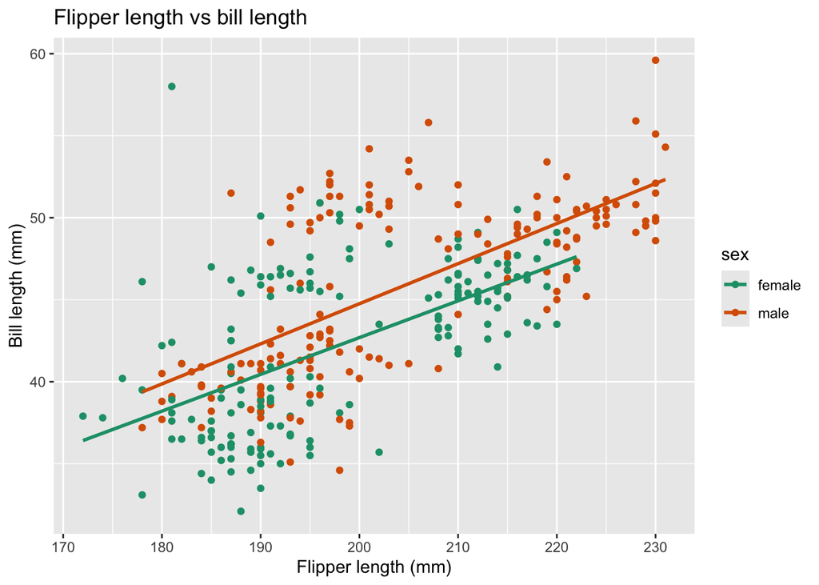

```r
ggplot(penguins_sm,
       aes(x = flipper_length_mm,
           y = bill_length_mm,
           color = sex)) +
  geom_point() +
  geom_smooth(method = "lm",
              se = FALSE) +
  scale_color_brewer(palette = "Dark2") +
  labs(
    title = "Flipper length vs bill length",
    x = "Flipper length (mm)",
    y = "Bill length (mm)",
  )
```

## Question 3

```r
model1 = lm(bill_length_mm ~ flipper_length_mm,
            data = penguins_sm)

summary(model1)
```

```
Call:
lm(formula = bill_length_mm ~ flipper_length_mm, data = penguins_sm)

Residuals:
    Min      1Q  Median      3Q     Max
-8.6367 -2.6981 -0.5788  2.0663 19.0953

Coefficients:
                  Estimate Std. Error t value Pr(>|t|)
(Intercept)       -7.21856    3.27175  -2.206    0.028 *
flipper_length_mm  0.25482    0.01624  15.691   <2e-16 ***
---
Signif. codes:  0 '***' 0.001 '**' 0.01 '*' 0.05 '.' 0.1 ' ' 1

Residual standard error: 4.148 on 331 degrees of freedom
Multiple R-squared:  0.4265,    Adjusted R-squared:  0.4248
F-statistic: 246.2 on 1 and 331 DF,  p-value: < 2.2e-16
```

The equation for this model is: Bill Length = -7.218 + .2548*flipper_length_mm flipper length is a statistically significant predictor of bill length (p-value < 0.001). The $R^2$ is 0.4248, which means that 42.48% of the variability in bill length can be explained by flipper length.

for each additional mm of flipper length, we expect bill length to increase by 0.2548 mm.

## Question 4

```r
model2 = lm(bill_length_mm ~ flipper_length_mm + body_mass_g,
            data = penguins_sm)

summary(model2)
```

```
Call:
lm(formula = bill_length_mm ~ flipper_length_mm + body_mass_g,
    data = penguins_sm)

Residuals:
    Min      1Q  Median      3Q     Max
-8.8251 -2.6432 -0.7281  2.0229 18.8227

Coefficients:
                    Estimate Std. Error t value Pr(>|t|)
(Intercept)       -3.9812079  4.7215540  -0.843    0.400
flipper_length_mm  0.2271747  0.0333014   6.822 4.31e-11 ***
body_mass_g        0.0005513  0.0005797   0.951    0.342
---
Signif. codes:  0 '***' 0.001 '**' 0.01 '*' 0.05 '.' 0.1 ' ' 1

Residual standard error: 4.148 on 330 degrees of freedom
Multiple R-squared:  0.4281,    Adjusted R-squared:  0.4246
F-statistic: 123.5 on 2 and 330 DF,  p-value: < 2.2e-16
```

The equation for this model is: Bill Length = -3.98 + .2272*flipper_length_mm + .00055*body_mass_g flipper length is a statistically significant predictor of bill length (p-value < .001), but body mass is not (p-value = 0.342). The $R^2$ is 0.4246, which means that 42.46% of the variability in bill length can be explained by flipper length and body mass.

For each additional mm of flipper length, we expect bill length to increase by 0.2272 mm, and for each additional gram of body mass, we expect bill length to increase by 0.00055 mm.

## Question 5

```r
model3 = lm(bill_length_mm ~ body_mass_g + sex,
            data = penguins_sm)

summary(model3)
```

```
Call:
lm(formula = bill_length_mm ~ body_mass_g + sex, data = penguins_sm)

Residuals:
     Min       1Q   Median       3Q      Max
-10.7196  -3.2501  -0.7724   2.5415  16.4992

Coefficients:
             Estimate Std. Error t value Pr(>|t|)
(Intercept) 2.791e+01  1.323e+00  21.095   <2e-16 ***
body_mass_g 3.674e-03  3.309e-04  11.102   <2e-16 ***
sexmale     1.247e+00  5.321e-01   2.344   0.0197 *
---
Signif. codes:  0 '***' 0.001 '**' 0.01 '*' 0.05 '.' 0.1 ' ' 1

Residual standard error: 4.395 on 330 degrees of freedom
Multiple R-squared:  0.3581,    Adjusted R-squared:  0.3542
F-statistic: 92.06 on 2 and 330 DF,  p-value: < 2.2e-16
```

The equation for this model is: Bill Length = 2.791e+01 + 3.67e-03*body_mass_g + 1.247e+00*sexmale. Both body mass and sex are statistically significant at the 5% level. The adjusted $R^2$ is .3542.

For each additional g of body weight, we can expect bill length to increase by .00367, and if the sex is male, we can expect bill length to increase by 1.247 mm.

## Question 6

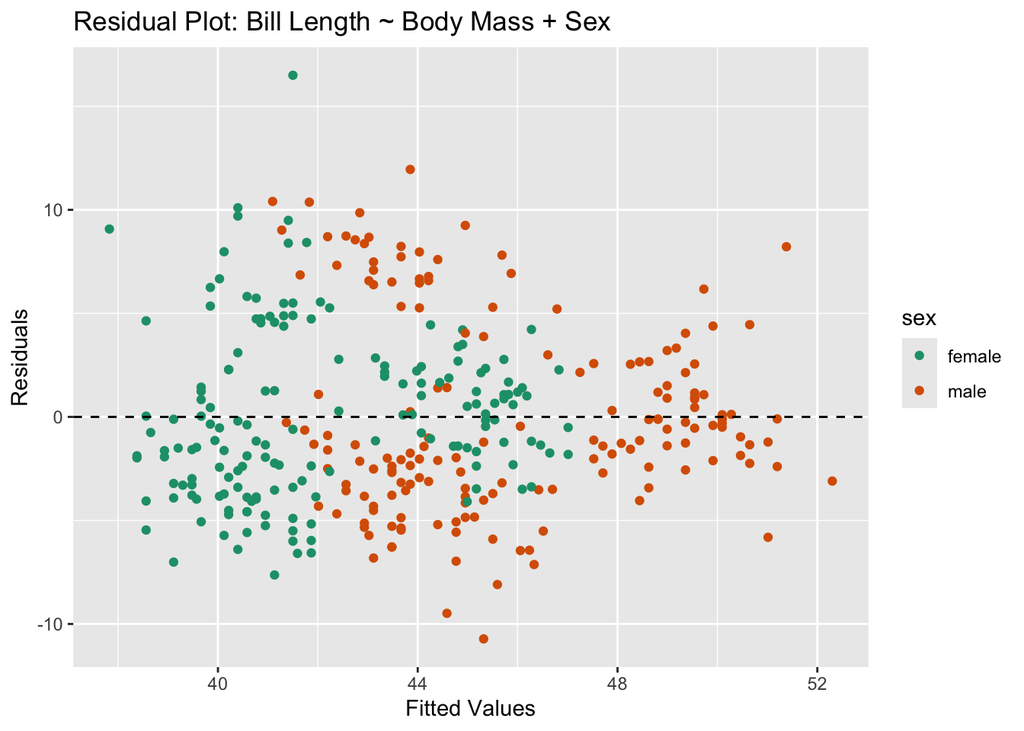

```r
ggplot(data = penguins_sm, aes(x = fitted(model3),
                               y = resid(model3),
                               color = sex)) +
  geom_point() +
  geom_hline(yintercept = 0,
             linetype = "dashed") +
  labs(
    title = "Residual Plot: Bill Length ~ Body Mass + Sex",
    x = "Fitted Values",
    y = "Residuals",
    color = "sex") +
  scale_color_brewer(palette = "Dark2")
```

No clear trend in residuals, aside from males generally having higher fitted values.

## Question 7

```r
model4 = lm(bill_length_mm ~ flipper_length_mm + body_mass_g + sex,
            data = penguins_sm)

summary(model4)
```

```
Call:
lm(formula = bill_length_mm ~ flipper_length_mm + body_mass_g +
    sex, data = penguins_sm)

Residuals:
    Min      1Q  Median      3Q     Max
-9.6131 -2.8005 -0.6307  2.1699 20.1682

Coefficients:
                    Estimate Std. Error t value Pr(>|t|)
(Intercept)       -8.0754117  4.6732129  -1.728   0.0849 .
flipper_length_mm  0.2672650  0.0335203   7.973 2.57e-14 ***
body_mass_g       -0.0006670  0.0006232  -1.070   0.2853
sexmale            2.3047154  0.5055670   4.559 7.27e-06 ***
---
Signif. codes:  0 '***' 0.001 '**' 0.01 '*' 0.05 '.' 0.1 ' ' 1

Residual standard error: 4.029 on 329 degrees of freedom
Multiple R-squared:  0.4621,    Adjusted R-squared:  0.4572
F-statistic:  94.2 on 3 and 329 DF,  p-value: < 2.2e-16
```

The equation for this model is: Bill Length = -8.075 + .2673*flipper_length_mm - .00067*body_mass_g + 2.304*sexmale. Flipper Length and sexmale are statistically significant at the 99% level, while body mass is not (p-value = 0.2852) is not significant. The adjusted $R^2$ is .4572.

As flipper length increases by 1 mm, bill length increases by .2673. As body mass increases by 1 gram, bill length decreases by .00067 mm. If a penguin is male, we can expect their bill to be 2.30 mm longer on average.

The body mass variable here is likely correlated with another variable, as its p-value and coefficient become essentially worthless when flipper length is added.